# Homework #2

Ozge Genc - BDA 503 - Fall 2017

I checked for a data set online and found Human Resources data-set on Kaggle. I thought I might find some interesting realtionships about the working conditions. I downloaded the csv file and import the data to RMarkdown by using read.csv function.

```r
getwd()
```

```
## [1] "C:/Users/Lenovo/Desktop"
```

```r
HumanResources <- read.csv("HR_comma_sep.csv")
```

I wanted to see a summary of the data. I see the name of the columns some simple statistical outputs like range, interquartile range, min and max.

```r
summary(HumanResources)
```

```
##  satisfaction_level last_evaluation  number_project  average_montly_hours
##  Min.   :0.0900     Min.   :0.3600   Min.   :2.000   Min.   : 96.0
##  1st Qu.:0.4400     1st Qu.:0.5600   1st Qu.:3.000   1st Qu.:156.0
##  Median :0.6400     Median :0.7200   Median :4.000   Median :200.0
##  Mean   :0.6128     Mean   :0.7161   Mean   :3.803   Mean   :201.1
##  3rd Qu.:0.8200     3rd Qu.:0.8700   3rd Qu.:5.000   3rd Qu.:245.0
##  Max.   :1.0000     Max.   :1.0000   Max.   :7.000   Max.   :310.0
##
##  time_spend_company Work_accident         left
##  Min.   : 2.000     Min.   :0.0000   Min.   :0.0000
##  1st Qu.: 3.000     1st Qu.:0.0000   1st Qu.:0.0000
##  Median : 3.000     Median :0.0000   Median :0.0000
##  Mean   : 3.498     Mean   :0.1446   Mean   :0.2381
##  3rd Qu.: 4.000     3rd Qu.:0.0000   3rd Qu.:0.0000
##  Max.   :10.000     Max.   :1.0000   Max.   :1.0000
##
##  promotion_last_5years         sales         salary
##  Min.   :0.00000       sales      :4140   high  :1237
##  1st Qu.:0.00000       technical  :2720   low   :7316
##  Median :0.00000       support    :2229   medium:6446
##  Mean   :0.02127       IT         :1227
##  3rd Qu.:0.00000       product_mng: 902
##  Max.   :1.00000       marketing  : 858
##                        (Other)    :2923
```

```r
str("HumanResources")
```

```
##  chr "HumanResources"
```

```r
names("HumanResources")
```

[output not shown]

After I called ggplot2 to make some simple diagrams. I wanted to see the bar chart of number of the project that the workers do.

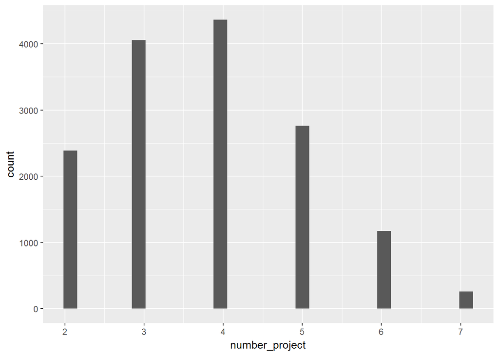

```r
library(ggplot2)
qplot(x=number_project, data=HumanResources)
```

After I wanted to checked the monthly hours that the workers work. I decided the bin range to be 10.

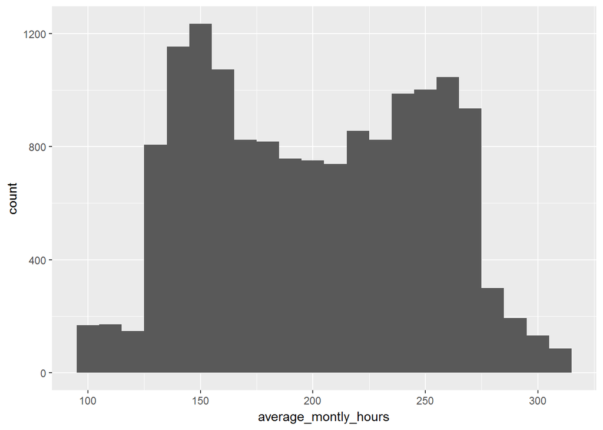

```r
qplot(x=average_montly_hours, data=HumanResources, binwidth=10)
```

It made me wonder if there is any relationship between the average monthly hours and the number of the project that workers take. I used facet_wrap function. Then when I checked the below charts I can say that the workers who take more projects are tend to work more hours.

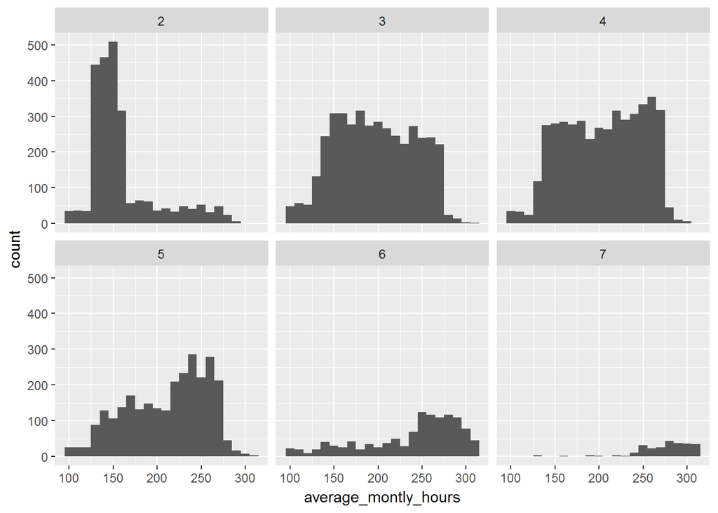

```r
qplot(x=average_montly_hours, data=HumanResources, binwidth=10)+
  facet_wrap(~number_project)
```